# Peces Especies

## Leyendo Base de Datos.

```r
datos <- read.csv(file = "DatosEspecies.csv", encoding = "UTF-8")
```

Esta base de datos contiene algunas medidas productivas de diferentes especies acuícolas en los municipios del departamento de Risaralda, para los años **2014** y **2015**. Entre las medidas se encuentra el número de animales sembrados y cosechados, el peso promedio, la producción total y precio al productor. La base de datos puede ser descargada en el link https://drive.google.com/open?id=1cWSfqW4jnf0tZHy1HQ4cXr-IvmzTce-w

Esta fue creada a partir de las bases de datos proporcionadas por la Gobernación de Risaralda para los años 2014 y 2015, las cuales fueron consultadas y descargadas en Octubre de 2017, en los siguientes links:

**Año 2014** https://www.datos.gov.co/Agricultura-y-Desarrollo-Rural/Estadistica-2014-Acuicultura-por-Especies/6fmg-kn6d

**Año 2015** https://www.datos.gov.co/Agricultura-y-Desarrollo-Rural/Estadistica-2015-Acuicultura-por-Especies/msan-h2wb

### Resumen y Estructura de Datos.

```r
summary(datos)
```

```
##        X                   Municipio       Año
##  Min.   : 1.0   Belén de Umbría : 9   Min.   :2014
##  1st Qu.:23.5   Pereira         : 9   1st Qu.:2014
##  Median :46.0   Santa Rosa de C.: 9   Median :2014
##  Mean   :46.0   Dosquebradas    : 8   Mean   :2014
##  3rd Qu.:68.5   Quinchia        : 8   3rd Qu.:2015
##  Max.   :91.0   Mistrató        : 7   Max.   :2015
##                 (Other)         :41
##                    Especie   Animales.Sembrados Animales.Cosechados
##  CACHAMA               :13   Min.   :     50    Min.   :     50
##  CARPA                 : 8   1st Qu.:   2228    1st Qu.:   2090
##  MOJARRA CHITRALA      : 3   Median :  13680    Median :  12350
##  TILAPIA NEGRA         :26   Mean   : 104332    Mean   :  94288
##  TILAPIA O MOJARRA ROJA:28   3rd Qu.:  39382    3rd Qu.:  35894
##  TRUCHA                :13   Max.   :1953895    Max.   :1904000
##
##  Peso.Promedio     Producción       Precio.Productor
##  Min.   :250.0   Min.   :    15.0   Min.   : 4000
##  1st Qu.:300.0   1st Qu.:   841.5   1st Qu.: 6800
##  Median :320.0   Median :  4185.0   Median : 7200
##  Mean   :351.5   Mean   : 34807.4   Mean   : 7600
##  3rd Qu.:400.0   3rd Qu.: 12639.5   3rd Qu.: 8000
##  Max.   :600.0   Max.   :768528.0   Max.   :12000
##
```

```r
str(datos)
```

```
## 'data.frame':    91 obs. of  9 variables:
##  $ X                  : int  1 2 3 4 5 6 7 8 9 10 ...
##  $ Municipio          : Factor w/ 14 levels "Apia","Balboa",..: 1 1 1 2 3 3 3 3 4 4 ...
##  $ Año                : int  2014 2014 2014 2014 2014 2014 2014 2014 2014 2014 ...
##  $ Especie            : Factor w/ 6 levels "CACHAMA","CARPA",..: 2 4 5 5 1 6 4 5 5 4 ...
##  $ Animales.Sembrados : int  400 23820 35730 25510 8000 44500 41200 312700 12990 11496 ...
##  $ Animales.Cosechados: int  350 22629 33943 22560 7500 40050 37080 281430 11000 10000 ...
##  $ Peso.Promedio      : int  400 350 350 330 500 450 320 300 400 450 ...
##  $ Producción         : int  140 7920 11880 7445 3750 18023 11866 84429 4400 4500 ...
##  $ Precio.Productor   : int  8000 8000 8000 7500 6500 9000 7000 7000 8000 7500 ...
```

Para este caso necesitamos que la variable **Año** sea tenido en cuenta como un factor y no como un entero.

### Cargando paquetes a ser usados.

```r
library(dplyr)
library(tidyr)
library(ggplot2)
library(ggthemes)
library(DT)
library(pander)
```

Cambiamos la clase de la variable Año, de entero a factor, eliminamos la columna X y además se divide la producción entre 1000, con el fin de expresar esta en toneladas.

```r
datos1 <- datos %>%
        select(-X) %>%
        mutate(Año = factor(Año),
               Producción = Producción/1000)

str(datos1)
```

```
## 'data.frame':    91 obs. of  8 variables:
##  $ Municipio          : Factor w/ 14 levels "Apia","Balboa",..: 1 1 1 2 3 3 3 3 4 4 ...
##  $ Año                : Factor w/ 2 levels "2014","2015": 1 1 1 1 1 1 1 1 1 1 ...
##  $ Especie            : Factor w/ 6 levels "CACHAMA","CARPA",..: 2 4 5 5 1 6 4 5 5 4 ...
##  $ Animales.Sembrados : int  400 23820 35730 25510 8000 44500 41200 312700 12990 11496 ...
##  $ Animales.Cosechados: int  350 22629 33943 22560 7500 40050 37080 281430 11000 10000 ...
##  $ Peso.Promedio      : int  400 350 350 330 500 450 320 300 400 450 ...
##  $ Producción         : num  0.14 7.92 11.88 7.45 3.75 ...
##  $ Precio.Productor   : int  8000 8000 8000 7500 6500 9000 7000 7000 8000 7500 ...
```

## Exploración de Datos.

### Distribución producción, siembra y cosecha 2014 - 2015.

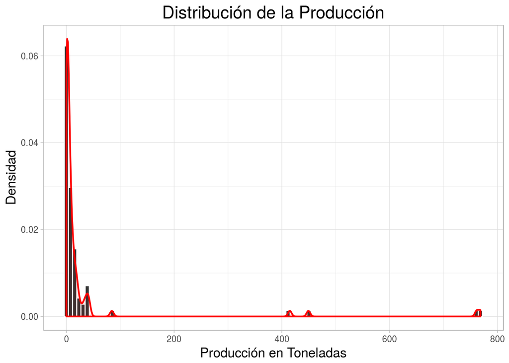

```r
ggplot(data = datos1, aes(x = Producción)) +
        geom_histogram(aes(y = ..density..), bins = 100, color = "white", fill = "gray20") +
        geom_density(alpha = 0.07, size = 0.8, fill = "red", colour = "red") +
        labs(x = "Producción en Toneladas",
             y = "Densidad",
             title = "Distribución de la Producción") +
        theme_light() +
        theme(plot.title = element_text(hjust = 0.5, size = 17),
              axis.title.x = element_text(size = 13),
              axis.title.y = element_text(size = 13))
```

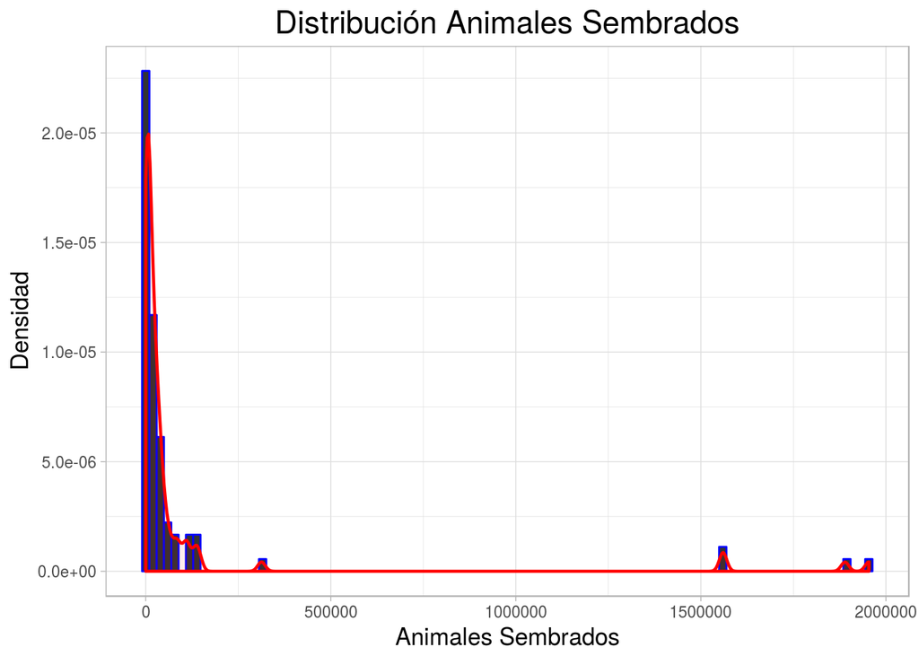

```r
ggplot(data = datos1, aes(x = Animales.Sembrados)) +
        geom_histogram(aes(y = ..density..), bins = 100, color = "Blue", fill = "gray20") +
        geom_density(alpha = 0.07, size = 0.8, fill = "red", colour = "red") +
        labs(x = "Animales Sembrados",
             y = "Densidad",
             title = "Distribución Animales Sembrados") +
        theme_light() +
        theme(plot.title = element_text(hjust = 0.5, size = 17),
              axis.title.x = element_text(size = 13),
              axis.title.y = element_text(size = 13))
```

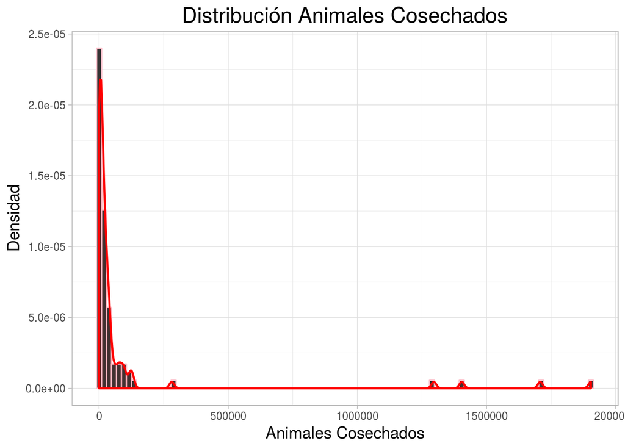

```r
ggplot(data = datos1, aes(x = Animales.Cosechados)) +
        geom_histogram(aes(y = ..density..), bins = 100, color = "Pink", fill = "gray20") +
        geom_density(alpha = 0.07, size = 0.8, fill = "red", colour = "red") +
        labs(x = "Animales Cosechados",
             y = "Densidad",
             title = "Distribución Animales Cosechados") +
        theme_light() +
        theme(plot.title = element_text(hjust = 0.5, size = 17),
              axis.title.x = element_text(size = 13),
              axis.title.y = element_text(size = 13))
```

Pasamos de formato ancho a formato largo, con el fin de facilitar algunas gráficas y mediciones.

```r
datos2 <- datos1 %>%
        gather(key = Variable,
               value = Valor,
               -c(1:3))
```

### Resumen General.

```r
datos22 <- datos2 %>%
        group_by(Variable, Especie, Año) %>%
        summarise(Minimo = min(Valor),
                  Maximo = max(Valor),
                  Promedio = round(mean(Valor), digits = 2),
                  Desviacion = round(sd(Valor), digits = 2))

datatable(datos22)
```

|  | Variable | Especie | Año | Minimo | Maximo | Promedio | Desviacion |
| --- | --- | --- | --- | --- | --- | --- | --- |
| 1 | Animales.Cosechados | CACHAMA | 2014 | 120 | 31860 | 7119.25 | 10533.47 |
| 2 | Animales.Cosechados | CACHAMA | 2015 | 600 | 27000 | 8921.2 | 10640.76 |
| 3 | Animales.Cosechados | CARPA | 2014 | 50 | 2150 | 1137.5 | 1091.16 |
| 4 | Animales.Cosechados | CARPA | 2015 | 380 | 5850 | 2451.25 | 2367.35 |
| 5 | Animales.Cosechados | MOJARRA CHITRALA | 2014 | 765 | 93500 | 47132.5 | 65573.55 |
| 6 | Animales.Cosechados | MOJARRA CHITRALA | 2015 | 93500 | 93500 | 93500 |  |
| 7 | Animales.Cosechados | TILAPIA NEGRA | 2014 | 270 | 41000 | 15656.62 | 15479.95 |
| 8 | Animales.Cosechados | TILAPIA NEGRA | 2015 | 176 | 118030 | 25311.15 | 32932.44 |
| 9 | Animales.Cosechados | TILAPIA O MOJARRA ROJA | 2014 | 1500 | 1296000 | 143101.64 | 339883.98 |
| 10 | Animales.Cosechados | TILAPIA O MOJARRA ROJA | 2015 | 1020 | 1404000 | 138583.14 | 366071.39 |

[output cut: 50 more lines]

### Resumen por Municipio.

```r
datos23 <- datos2 %>%
        group_by(Municipio, Variable, Año) %>%
        summarise(Minimo = min(Valor),
                  Maximo = max(Valor),
                  Promedio = round(mean(Valor), digits = 2),
                  Desviacion = round(sd(Valor), digits = 2))

datatable(datos23)
```

|  | Municipio | Variable | Año | Minimo | Maximo | Promedio | Desviacion |
| --- | --- | --- | --- | --- | --- | --- | --- |
| 1 | Apia | Animales.Cosechados | 2014 | 350 | 33943 | 18974 | 17092.15 |
| 2 | Apia | Animales.Cosechados | 2015 | 380 | 37550 | 20276.67 | 18723.34 |
| 3 | Apia | Animales.Sembrados | 2014 | 400 | 35730 | 19983.33 | 17974.77 |
| 4 | Apia | Animales.Sembrados | 2015 | 500 | 40200 | 21866.67 | 20023.07 |
| 5 | Apia | Peso.Promedio | 2014 | 350 | 400 | 366.67 | 28.87 |
| 6 | Apia | Peso.Promedio | 2015 | 350 | 400 | 366.67 | 28.87 |
| 7 | Apia | Precio.Productor | 2014 | 8000 | 8000 | 8000 | 0 |
| 8 | Apia | Precio.Productor | 2015 | 6500 | 7500 | 6933.33 | 513.16 |
| 9 | Apia | Producción | 2014 | 0.14 | 11.88 | 6.65 | 5.97 |
| 10 | Apia | Producción | 2015 | 0.152 | 13.143 | 7.1 | 6.54 |

[output cut: 130 more lines]

### Animales Cosechados.

```r
cosechados <- datos2 %>%
        group_by(Especie, Año) %>%
        filter(Variable == "Animales.Cosechados") %>%
        summarise(Total = sum(Valor)) %>%
        arrange(Total)

pander(cosechados, justify = "right")
```

| Especie | Año | Total |
| --- | --- | --- |
| CARPA | 2014 | 4550 |
| CARPA | 2015 | 9805 |
| CACHAMA | 2015 | 44606 |
| CACHAMA | 2014 | 56954 |
| MOJARRA CHITRALA | 2015 | 93500 |
| MOJARRA CHITRALA | 2014 | 94265 |
| TILAPIA NEGRA | 2014 | 203536 |
| TILAPIA NEGRA | 2015 | 329045 |
| TRUCHA | 2015 | 1816121 |
| TILAPIA O MOJARRA ROJA | 2015 | 1940164 |
| TRUCHA | 2014 | 1984200 |
| TILAPIA O MOJARRA ROJA | 2014 | 2003423 |

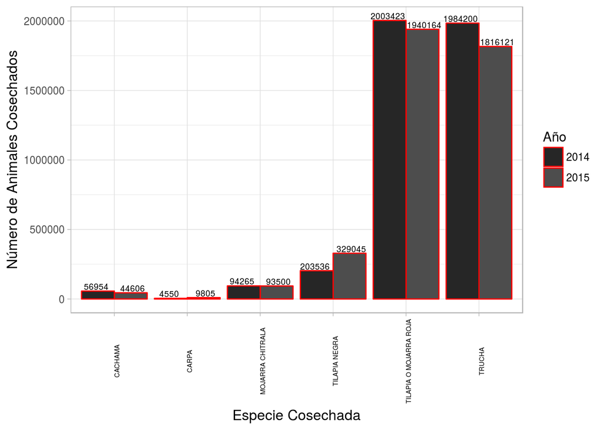

```r
ggplot(data = cosechados, aes(x = Especie, y = Total, group = Año)) +
        geom_bar(aes(fill=Año), position = "dodge", stat = "identity", color = "Red") +
        labs(x = "Especie Cosechada",
             y = "Número de Animales Cosechados") +
        scale_fill_manual(values = c("gray15", "gray30")) +
        geom_text(aes(label = Total),
                  position = position_dodge(width = 1), vjust = -0.2,
                  color = "Black", size = 2.5) +
        theme_light() +
        theme(axis.title.x = element_text(size = 12),
              axis.title.y = element_text(size = 12),
              axis.text.x = element_text(angle = 90, size = 5.5, color = "Black"))
```

### Porcentaje de Cosecha.

```r
porcentajes <- datos2 %>%
        group_by(Especie, Año, Variable) %>%
        summarise(Total = sum(Valor)) %>%
        filter(Variable %in% c("Animales.Cosechados", "Animales.Sembrados"))

porcentajes2 <- porcentajes %>%
        spread(key = Variable,
               value = Total)

porcentajes2.1 <- porcentajes2 %>%
        mutate(Porcentaje = round(Animales.Cosechados/Animales.Sembrados * 100, digits = 2))

panderOptions("table.split.table", 100)
pander(porcentajes2.1, justify = c("right"))
```

| Especie | Año | Animales.Cosechados | Animales.Sembrados | Porcentaje |
| --- | --- | --- | --- | --- |
| CACHAMA | 2014 | 56954 | 62242 | 91.5 |
| CACHAMA | 2015 | 44606 | 49493 | 90.13 |
| CARPA | 2014 | 4550 | 4550 | 100 |
| CARPA | 2015 | 9805 | 10950 | 89.54 |
| MOJARRA CHITRALA | 2014 | 94265 | 110850 | 85.04 |
| MOJARRA CHITRALA | 2015 | 93500 | 110000 | 85 |
| TILAPIA NEGRA | 2014 | 203536 | 232223 | 87.65 |
| TILAPIA NEGRA | 2015 | 329045 | 365117 | 90.12 |
| TILAPIA O MOJARRA ROJA | 2014 | 2003423 | 2336988 | 85.73 |
| TILAPIA O MOJARRA ROJA | 2015 | 1940164 | 2159353 | 89.85 |
| TRUCHA | 2014 | 1984200 | 2042895 | 97.13 |
| TRUCHA | 2015 | 1816121 | 2009585 | 90.37 |

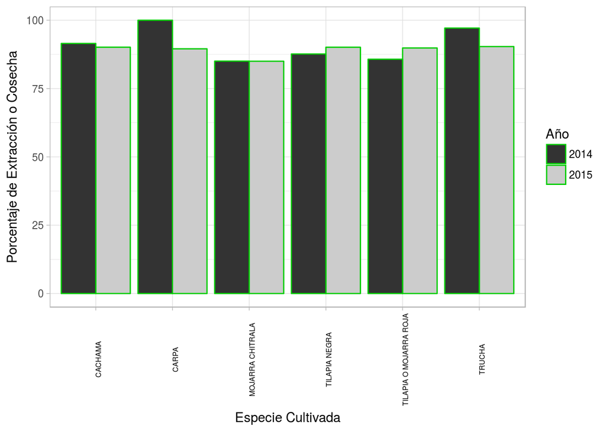

```r
ggplot(data = porcentajes2.1, aes(x = Especie, y = Porcentaje, group = Año)) +
        geom_bar(aes(fill = Año), position = "dodge", stat = "identity", color = "green3") +
        labs(x = "Especie Cultivada",
             y = "Porcentaje de Extracción o Cosecha") +
        scale_fill_grey() +
        theme_light() +
        theme(axis.text.x = element_text(color = "Black", angle = 90, size = 6))
```

### Especie más producida.

```r
especie <- datos2 %>%
        group_by(Especie, Año) %>%
        filter(Variable == "Producción") %>%
        summarise(Total = sum(Valor))

pander(especie)
```

| Especie | Año | Total |
| --- | --- | --- |
| CACHAMA | 2014 | 29.54 |
| CACHAMA | 2015 | 24.07 |
| CARPA | 2014 | 1.915 |
| CARPA | 2015 | 3.73 |
| MOJARRA CHITRALA | 2014 | 42.27 |
| MOJARRA CHITRALA | 2015 | 42.08 |
| TILAPIA NEGRA | 2014 | 67.04 |
| TILAPIA NEGRA | 2015 | 107 |
| TILAPIA O MOJARRA ROJA | 2014 | 628.3 |
| TILAPIA O MOJARRA ROJA | 2015 | 617.2 |
| TRUCHA | 2014 | 792.4 |
| TRUCHA | 2015 | 811.9 |

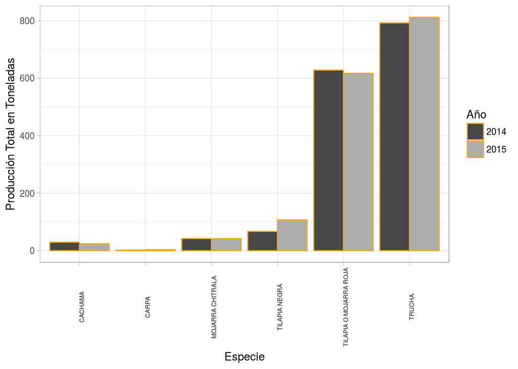

```r
ggplot(data = especie, aes(x = Especie, y = Total, group = Año)) +
        geom_bar(aes(fill = Año), position = "dodge", stat = "identity", color = "orange") +
        labs(x = "Especie",
             y = "Producción Total en Toneladas") +
        scale_fill_manual(values = c("gray28", "gray68")) +
        theme_light() +
        theme(axis.text.x = element_text(color = "gray10", angle = 90, size = 6))
```

### Municipio más productor.

```r
municipio <- datos2 %>%
        group_by(Municipio, Año) %>%
        filter(Variable == "Producción") %>%
        summarise(Total = sum(Valor)) %>%
        arrange(-Total)

datatable(municipio)
```

|  | Municipio | Año | Total |
| --- | --- | --- | --- |
| 1 | Santa Rosa de C. | 2015 | 831.718 |
| 2 | Santa Rosa de C. | 2014 | 800.132 |
| 3 | Pereira | 2015 | 508.455 |
| 4 | Pereira | 2014 | 484.861 |
| 5 | Belén de Umbría | 2014 | 118.068 |
| 6 | Belén de Umbría | 2015 | 87.721 |
| 7 | Santuario | 2015 | 44.714 |
| 8 | Santuario | 2014 | 40.476 |
| 9 | Quinchia | 2015 | 32.148 |
| 10 | Quinchia | 2014 | 30.928 |

[output cut: 18 more lines]

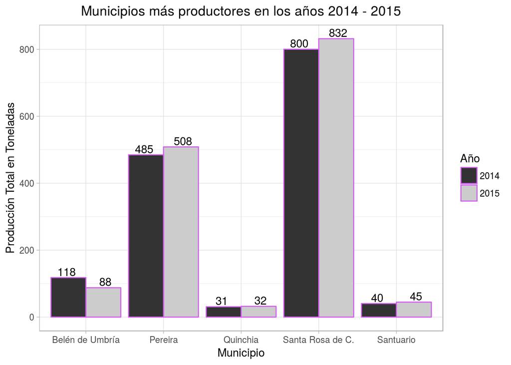

```r
municipio2 <- municipio[1:10, ]

ggplot(data = municipio2, aes(x = Municipio, y = Total, group = Año)) +
        geom_bar(aes(fill = Año), position = "dodge", stat = "identity",
                       color = "mediumorchid2") +
        labs(x = "Municipio",
             y = "Producción Total en Toneladas",
             title = "Municipios más productores en los años 2014 - 2015") +
        geom_text(aes(label = round(Total, 0)),
                  position = position_dodge(width = 1), vjust = -0.2) +
        scale_fill_grey() +
        theme_light() +
        theme(plot.title = element_text(hjust = 0.5))
```